Home > Archives > 数据清洗工具dplyr介绍

# 数据清洗工具dplyr介绍

Publish: April 2, 2015

# 使用dplyr帮助数据探索

zengfan

2015年2月15日

在数据的世界中，大部分的工作都是与数据准备有关。在其它行业，许多工作也是类似的：准备的工作占用大部分的时间，比如烹饪、木工等。

所以一旦称为一个数据科学家，你需要做好80%的时间都用来数据探索的心理准备。具体来说，数据获取、数据分组、数据清洗、数据统计、融合不同的数据集到一个表格中等工作将会占用你大部分时间，最开始，你处理的数据格式是txt、csv或者excel格式的小型文件，之后，你的工作还会涉及到各种关系型数据库、非关系型数据库、分布式并行数据库例如HDFS等等。

分析数据工作是往往从做很小的数据操作开始的，如果是格式修改方面的工作，可是使用Excel这样的工具，而Excel确实在这份面做得很好。然而，随着数据探索的深入，往往会到达一个技术积累的瓶颈，因为这时你需要更加复杂的数据可视化或者机器学习的技术来帮助你进行数据的探索，同时，你需要新的工作来完成更加复杂的数据整理的工作。

## 使用dplyr数据操作

对於大多数情况，dplyr都是一个不错的数据整理的工具，它包含5个基本的数据整理的功能，分别是：

– 根据行（观测）选择子集—-filter() – 根据列（变量）选择子集—-select() – 增加新的变量—-mutate() – 排序Sorting—-arrange() – 聚合统计（Aggregating）—-summarize()

以上这些都是数据操作的基础，它们非常重要。实际每天都会用到，而使用dplyr处理这些工作非常的简单。

而且，dplyr提供了一种强大的“chaining”机制，使得对数据的操作像“流”一样。这种“chaining”机制还可以和R里强大的数据可视化工具ggplot2中的功能一起使用，达到快速进行数据探索和分析的目的。

## dplyr命令

下面对几种重要的数据操作进行简单介绍。

### filter()

根据行选择数据集

filter() 选择符合行条件的数据集。

```r
#如果没有这两个包，可以通过
#install.packages('dplyr')
#install.packages('ggplot2')
#进行安装
library(dplyr)
library(ggplot2)

head(diamonds,5)
```

```
##   carat     cut color clarity depth table price    x    y    z
## 1  0.23   Ideal     E     SI2  61.5    55   326 3.95 3.98 2.43
## 2  0.21 Premium     E     SI1  59.8    61   326 3.89 3.84 2.31
## 3  0.23    Good     E     VS1  56.9    65   327 4.05 4.07 2.31
## 4  0.29 Premium     I     VS2  62.4    58   334 4.20 4.23 2.63
## 5  0.31    Good     J     SI2  63.3    58   335 4.34 4.35 2.75
```

```r
#我们在这里选择了diamonds中 cut=="Ideal"的数据。
df.diamonds_ideal <- filter(diamonds, cut=="Ideal")
```

### select()

Select()根据列进行子集的选择。

```r
# 观察数据cut==“Ideal”的diamonds数据样本
head(df.diamonds_ideal,3)
```

```
##   carat   cut color clarity depth table price    x    y    z
## 1  0.23 Ideal     E     SI2  61.5    55   326 3.95 3.98 2.43
## 2  0.23 Ideal     J     VS1  62.8    56   340 3.93 3.90 2.46
## 3  0.31 Ideal     J     SI2  62.2    54   344 4.35 4.37 2.71
```

```r
# 选择需要观察的列
df.diamonds_ideal <- select(df.diamonds_ideal, carat, cut, color, price, clarity)

head(df.diamonds_ideal)
```

```
##   carat   cut color price clarity
## 1  0.23 Ideal     E   326     SI2
## 2  0.23 Ideal     J   340     VS1
## 3  0.31 Ideal     J   344     SI2
## 4  0.30 Ideal     I   348     SI2
## 5  0.33 Ideal     I   403     SI2
## 6  0.33 Ideal     I   403     SI2
```

### mutate()

Mutate()增加新的列到你的数据集中。

```r
#Umutate()增加了price_per_carat这一列
df.diamonds_ideal <- mutate(df.diamonds_ideal, price_per_carat = price/carat)

head(df.diamonds_ideal)
```

```
##   carat   cut color price clarity price_per_carat
## 1  0.23 Ideal     E   326     SI2        1417.391
## 2  0.23 Ideal     J   340     VS1        1478.261
## 3  0.31 Ideal     J   344     SI2        1109.677
## 4  0.30 Ideal     I   348     SI2        1160.000
## 5  0.33 Ideal     I   403     SI2        1221.212
## 6  0.33 Ideal     I   403     SI2        1221.212
```

### arrange()

Arrange()对你的数据进行排列，在R原始包，一般使用order()方法完成，但是会有点麻烦。 接下来，将通过一个简单的生成的数据框的排序介绍arrange()方法。

```r
df.disordered_data <- data.frame(num_var = c(2,3,5,1,4))

head(df.disordered_data)
```

```
##   num_var
## 1       2
## 2       3
## 3       5
## 4       1
## 5       4
```

```r
# 使用arrange()进行排序
arrange(df.disordered_data, num_var)
```

```
##   num_var
## 1       1
## 2       2
## 3       3
## 4       4
## 5       5
```

```r
# 降序
arrange(df.disordered_data, desc(num_var))
```

```
##   num_var
## 1       5
## 2       4
## 3       3
## 4       2
## 5       1
```

上面这个例子看似用处不大，它往往和其他的操作在一起才能更好地发挥作用。

### summarize()

Summarize()总结统计信息， allows you to compute summary statistics.

下面这个例子看似用处不大，但是它往往和其他的操作比如group_by()在一起能更好地发挥作用。

```r
summarize(df.diamonds_ideal, avg_price = mean(price, na.rm = TRUE) )
```

```
##   avg_price
## 1  3457.542
```

### “Chaining”

dplyr强大的地方在于你能够将不同的数据操作“chain”在一起，甚至可以和其它包种的命令和函数“chain”在一起，这其中包括ggplot2可视化包。

#### %>% 操作符

“chain”命令在dplyr语法中，我们使用%>%，这和Unix“pipe”命令类似。 具体来说我们使用 %>%操作符连接不同的命令，一个命令的输出是另一个命令的输入，下面将上面介绍的三个操作“chain”到一起：

```r
# 选择cut=='Ideal' 的数据集（filter）
# 选择关心的列（变量）： carat, cut, color, price, clarity（select）
# 增加 price_per_carat变量 (mutate)

df.diamonds_ideal_chained <- diamonds %>%
                              filter(cut=="Ideal") %>%
                              select(carat, cut, color, price, clarity) %>%
                              mutate(price_per_carat = price/carat)

head(df.diamonds_ideal_chained)
```

```
##   carat   cut color price clarity price_per_carat
## 1  0.23 Ideal     E   326     SI2        1417.391
## 2  0.23 Ideal     J   340     VS1        1478.261
## 3  0.31 Ideal     J   344     SI2        1109.677
## 4  0.30 Ideal     I   348     SI2        1160.000
## 5  0.33 Ideal     I   403     SI2        1221.212
## 6  0.33 Ideal     I   403     SI2        1221.212
```

更详细一点，上面我们通过“chain”不同的命令，来生成一个新的子集，后面每个命令的输入都是前一个命令的输出。

## 使用dplyr 和ggplot2进行快速的数据探索

上面这些例子非常简单，更加有用的使用方法是使用更复杂的使用场景来进行数据操作并且进行可视化，比如：

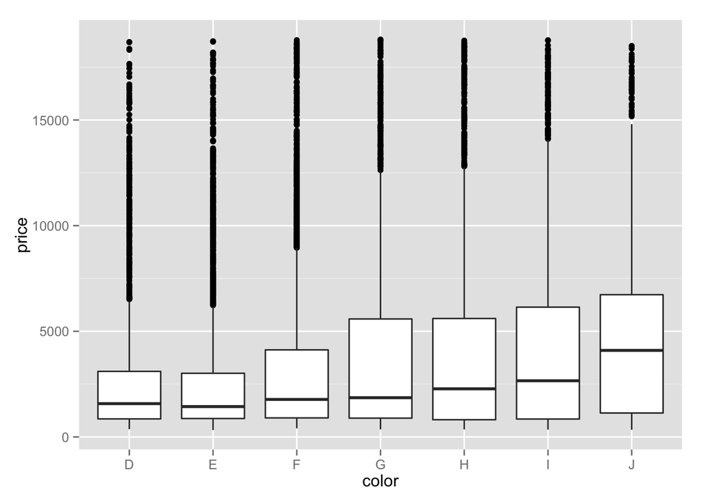

```r
#使用 dplyr + ggplot2描述Ideal-cut的价格分布
diamonds %>%
  filter(cut == "Ideal") %>%
  ggplot(aes(x=color,y=price)) +
    geom_boxplot()
```

又比如：

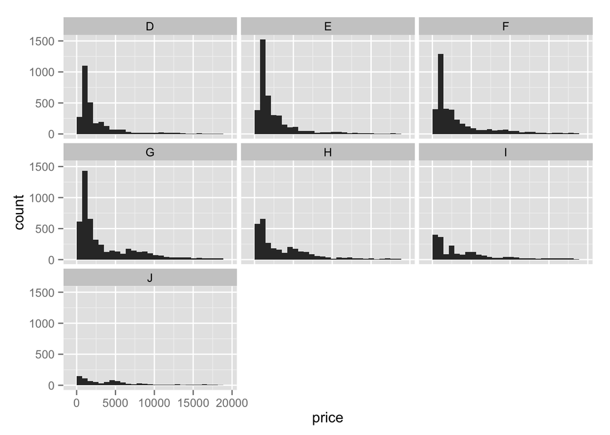

```r
#使用 dplyr + ggplot画多个直方图
#根据钻石颜色的不同进行分组画图描述他们的价格的分布
# dplyr + ggplot

diamonds %>%
  filter(cut == "Ideal") %>%
  ggplot(aes(price)) +
    geom_histogram(binwidth=700) +
    facet_wrap(~ color)
```

这里是简单的功能探索，这个5行代码所实现的分组图形，在excel中，可能需要数小时，由此可见一斑。

## 一个数据科学的入门建议

使用dplyr进行简单的数据科学入门，你需要掌握这几个简单但是重要的知识：

– 5个基本操作 – 3个基本的可视化方法: 线图，散点图，直方图 – 图形的分组 – chaining概念

这些都是数据工作非常基本而简单的技能，以后会慢慢介绍更多的入门级别的文章。

声明: 本文采用 [BY-NC-SA](http://creativecommons.org/licenses/by-nc-sa/3.0/) 授权。转载请注明转自: tegulia

« R可视化_ggplot2之因子水平在作图中的应用